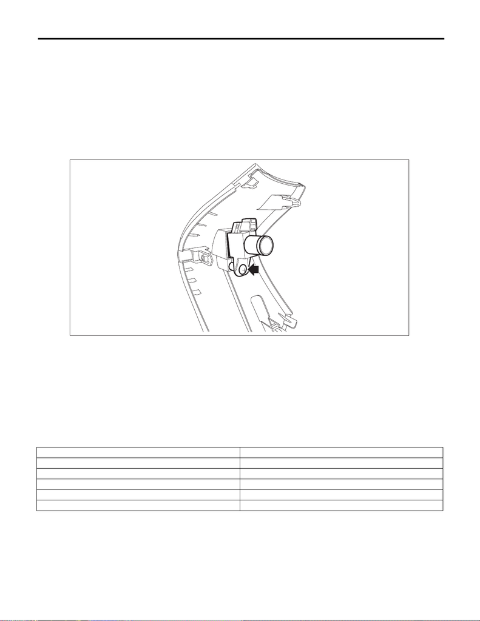

AC-77

In-Vehicle Sensor (Auto A/C Model)

HVAC SYSTEM (HEATER, VENTILATOR AND A/C)

23.In-Vehicle Sensor (Auto A/C Model)

A: REMOVAL

1) Disconnect the battery ground cable and wait for at least 60 seconds before starting work. <Ref. to NT-5,

BATTERY, NOTE, Note.>

NOTE:

For models other than STI model, disconnect the ground terminal from battery sensor.

2) Remove the cover assembly - instrument panel LWR driver INN. <Ref. to EI-61, REMOVAL, Instrument

Panel Lower Cover.>

3) Release the claws and remove the cover switch - starter. (Keyless access models)

4) Remove the screws, and then remove the in-vehicle sensor.

B: INSTALLATION

1) Install the in-vehicle sensor.

2) Install the cover switch - starter. (Keyless access models)

3) Install the cover assembly - instrument panel LWR driver INN.

4) Connect the battery ground terminal. <Ref. to NT-5, BATTERY, NOTE, Note.>

NOTE:

For models other than STI model, connect the ground terminal to battery sensor.

C: INSPECTION

1) Set the vehicle to the following conditions.

Item Condition

Ignition switch ON

A/C switch ON

Temperature adjustment dial HI (MAX HOT)

Air flow control dial or switch DEF

Fan dial HI (MAX)

AC-03557

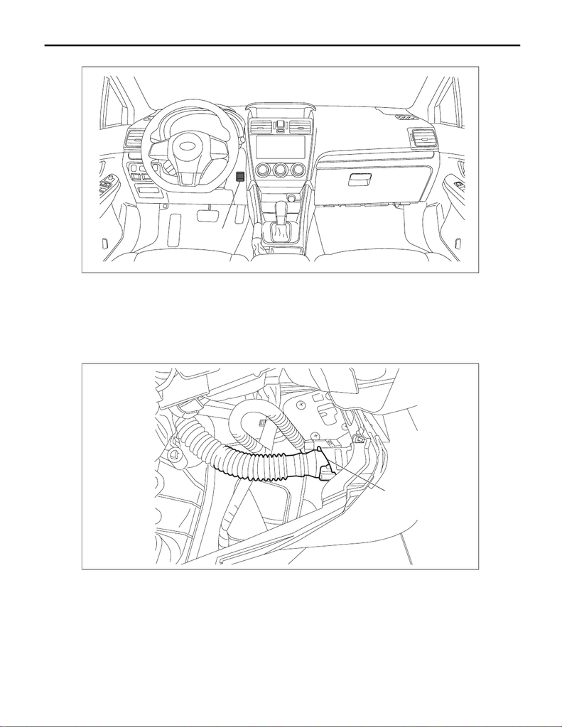

AC-78

In-Vehicle Sensor (Auto A/C Model)

HVAC SYSTEM (HEATER, VENTILATOR AND A/C)

2) Check the suction port (A) for in-vehicle sensor of the cover assembly - instrument panel LWR driver INN.

(1) Put a strip of paper close to the front side of the suction port (A).

(2) Can you see the paper moving towards the port and the air being sucked into the port?

CAUTION:

Be careful not to let the paper get sucked into the port.

• Yes → Go to step 5).

• No → Go to step 3).

3) Pull out the cover assembly - instrument panel LWR driver INN, and check the aspirator hose (A).

(1) Are the aspirator hoses on both sides of the case and sensor connected securely?

(2) Is the aspirator hose free from any kinks or cracks?

• Yes → Go to step 4).

• No → Repair or replace the aspirator hose if necessary.

4) Check if there is anything that affects sensing, around the in-vehicle sensor.

(1) Is the in-vehicle sensor hole free from clogging?

(2) Is the peripheral area of in-vehicle sensor free from any heat-producing parts (such as audio, naviga-

tion system etc.)?

• Yes → Go to step 5).

• No → Remove everything that affects sensing.

AC-03556

(A)

AC-02717

(A)

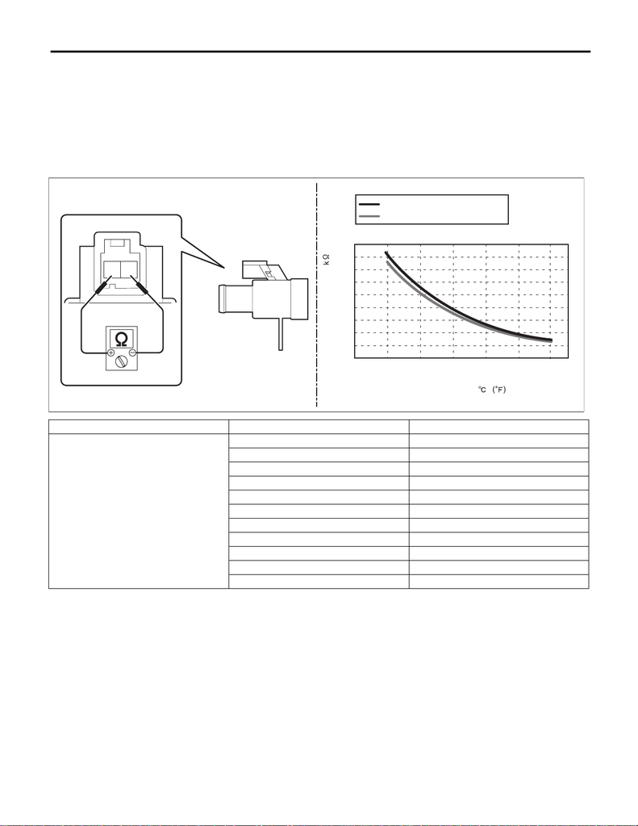

AC-79

In-Vehicle Sensor (Auto A/C Model)

HVAC SYSTEM (HEATER, VENTILATOR AND A/C)

5) Check in-vehicle sensor.

(1) Disconnect the connector.

(2) Measure the resistance between connector terminals.

Preparation tool:

Circuit tester

CAUTION:

During inspection, be careful not to touch the sensor end in order to avoid misjudgment due to body

temperature.

(3) Replace the in-vehicle sensor if the inspection result is not within the standard value.

Terminal No. Inspection conditions Standard

1 — 2

10°C 3.772 — 4.101 kΩ

15°C 3.096 — 3.338 kΩ

20°C 2.556 — 2.734 kΩ

25°C 2.121 — 2.251 kΩ

30°C 1.756 — 1.878 kΩ

35°C 1.462 — 1.574 kΩ

40°C 1.223 — 1.326 kΩ

45°C 1.028 — 1.122 kΩ

50°C 0.868 — 0.9542 kΩ

55°C 0.7363 — 0.8147 kΩ

60°C 0.6273 — 0.6984 kΩ

(32)

2

1

AC-02728

4.50

4.00

3.50

3.00

2.50

2.00

1.50

1.00

0.50

0.00

: STANDARD (MIN TOLERANCE)

: STANDARD (MAX TOLERANCE)

RESISTANCE VALUE

TEMPERATURE